# CFPS data analysis

Lin Wenzheng

2024-11-04

# Research Question

- The effect of parenting motivation on pro-environmental behaviors

# Parenting motivation

- 抚育动机(parenting motivation)，或抚育动机系统(parental caremotivational system)，是指一系列旨在照顾脆弱的年幼儿的情感和认知机制(Buckels et al.,2015; Griskevicius & Kenrick, 2013; Li et al., 2019)
- 使用CFPS 2018 qka202 作为代理变量
  - 2018: qka202

```
## [1] "期望孩子数（个）"
```

```
-   2020: qq9013
```

```
## [1] "照顾孩子时长（小时/天）"
```

# Pro-environmental outcomes

- 家庭人均水电与能源支出；控制家庭年收入与支出

```r
lapply(df2[, c("fp402","fp403","fp404","fp2","fml_count.x")], function(x) attr(x, "label"))
```

```
## $fp402
## [1] "每月水费（元）"
##
## $fp403
## [1] "每月电费（元）"
##
## $fp404
## [1] "每月燃料费（元）"
##
## $fp2
## [1] "在家吃饭的人数（人）"
##
## $fml_count.x
## [1] "加载变量：2018年家庭成员人数"
```

```r
lapply(df2[, c("finc","finc_est","finc1")], function(x) attr(x, "label"))
```

```
## $finc
## [1] "过去12个月总收入（元）"
##
## $finc_est
## [1] "过去12个月总收入区间-估计值（元）"
##
## $finc1
## [1] "总收入调整（元/年）"
```

```r
lapply(df2[, c("fexp","fexp_est","fexp1")], function(x) attr(x, "label"))
```

```
## $fexp
## [1] "过去12个月总支出（元）"
##
## $fexp_est
## [1] "过去12个月总支出区间-估计值（元）"
##
## $fexp1
## [1] "总支出调整（元/年）"
```

# Correlation matrix

- 由于CFPS数据为家庭调查嵌套数据，相关矩阵使用第二层数据
  - 部分第二层数据（家庭）为第一层数据（个体）aggregate 得到

```r
# lapply(df2[, c("qka202","qn6012","finc_corrected","fexp_corrected")], function(x) attr(x, "label"))
# pairs.panels(df5[,c(4:ncol(df5))], stars = TRUE)
```

# 家庭（第二层）数据分析

- 由于因变量水电能源支出为家庭层面数据，单层分析，使用一般线性回归

### 自变量：期望孩子数（个；家庭所有成员平均）

```r
my.lm1 <- lm(env_expavg2 ~  qka202 ,data=df5)
summary(my.lm1)
```

```
##
## Call:
## lm(formula = env_expavg2 ~ qka202, data = df5)
##
## Residuals:
##     Min      1Q  Median      3Q     Max
##  -86.91  -43.49  -19.35   18.13 2423.17
##
## Coefficients:
##             Estimate Std. Error t value Pr(>|t|)
## (Intercept)   86.906      2.292  37.917  < 2e-16 ***
## qka202        -5.040      1.053  -4.788 1.71e-06 ***
## ---
## Signif. codes:  0 '***' 0.001 '**' 0.01 '*' 0.05 '.' 0.1 ' ' 1
##
## Residual standard error: 81.13 on 9534 degrees of freedom
##   (419 observations deleted due to missingness)
## Multiple R-squared:  0.002399,   Adjusted R-squared:  0.002294
## F-statistic: 22.93 on 1 and 9534 DF,  p-value: 1.709e-06
```

- 期望孩子数显著负向预测了家庭水电能源支出

```r
my.lm2 <- lm(env_expavg2 ~ qka202 +age +finc_corrected+fexp_corrected,data=df5)
summary(my.lm2)
```

```
##
## Call:
## lm(formula = env_expavg2 ~ qka202 + age + finc_corrected + fexp_corrected,
##     data = df5)
##
## Residuals:
##     Min      1Q  Median      3Q     Max
## -189.92  -42.13  -19.54   15.28 2424.48
##
## Coefficients:
##                  Estimate Std. Error t value Pr(>|t|)
## (Intercept)     6.352e+01  3.248e+00  19.554  < 2e-16 ***
## qka202         -4.849e+00  1.081e+00  -4.485 7.39e-06 ***
## age             2.927e-01  5.796e-02   5.051 4.48e-07 ***
## finc_corrected  1.118e-04  1.267e-05   8.822  < 2e-16 ***
## fexp_corrected  4.745e-05  1.511e-05   3.141  0.00169 **
## ---
## Signif. codes:  0 '***' 0.001 '**' 0.01 '*' 0.05 '.' 0.1 ' ' 1
##
## Residual standard error: 79.63 on 9515 degrees of freedom
##   (435 observations deleted due to missingness)
## Multiple R-squared:  0.02138,    Adjusted R-squared:  0.02097
## F-statistic: 51.98 on 4 and 9515 DF,  p-value: < 2.2e-16
```

- 加入控制变量后，仍然显著

```r
my.lm3 <- lm(env_expratio ~ qka202 +age +finc_corrected,data=df5)
summary(my.lm3)
```

```
##
## Call:
## lm(formula = env_expratio ~ qka202 + age + finc_corrected, data = df5)
##
## Residuals:
##     Min      1Q  Median      3Q     Max
##  -0.114  -0.062  -0.054  -0.039 264.931
##
## Coefficients:
##                  Estimate Std. Error t value Pr(>|t|)
## (Intercept)     1.134e-01  1.189e-01   0.954    0.340
## qka202         -2.339e-02  3.990e-02  -0.586    0.558
## age            -1.846e-04  2.134e-03  -0.087    0.931
## finc_corrected  2.506e-08  3.869e-07   0.065    0.948
##
## Residual standard error: 2.937 on 9540 degrees of freedom
##   (411 observations deleted due to missingness)
## Multiple R-squared:  4.497e-05,  Adjusted R-squared:  -0.0002695
## F-statistic: 0.143 on 3 and 9540 DF,  p-value: 0.9342
```

```r
my.lm4 <- lm(env_expavg2_20 ~ qka202 +age +finc_corrected+ fexp_corrected,data=df6)
summary(my.lm4)
```

```
##
## Call:
## lm(formula = env_expavg2_20 ~ qka202 + age + finc_corrected +
##     fexp_corrected, data = df6)
##
## Residuals:
##     Min      1Q  Median      3Q     Max
## -232.88  -46.09  -22.29   18.76 1515.75
##
## Coefficients:
##                  Estimate Std. Error t value Pr(>|t|)
## (Intercept)     6.565e+01  3.510e+00  18.706  < 2e-16 ***
## qka202         -3.378e+00  1.176e+00  -2.871   0.0041 **
## age             3.441e-01  6.273e-02   5.485 4.23e-08 ***
## finc_corrected  1.170e-04  1.351e-05   8.661  < 2e-16 ***
## fexp_corrected  3.370e-05  1.603e-05   2.102   0.0355 *
## ---
## Signif. codes:  0 '***' 0.001 '**' 0.01 '*' 0.05 '.' 0.1 ' ' 1
##
## Residual standard error: 84.81 on 9550 degrees of freedom
##   (498 observations deleted due to missingness)
## Multiple R-squared:  0.01819,    Adjusted R-squared:  0.01778
## F-statistic: 44.23 on 4 and 9550 DF,  p-value: < 2.2e-16
```

```r
my.lm5 <- lm(env_expratio_20 ~ qka202 +age +finc_corrected,data=df6)
summary(my.lm5)
```

```
##
## Call:
## lm(formula = env_expratio_20 ~ qka202 + age + finc_corrected,
##     data = df6)
##
## Residuals:
##     Min      1Q  Median      3Q     Max
##  -1.618  -0.144  -0.037   0.042 304.770
##
## Coefficients:
##                  Estimate Std. Error t value Pr(>|t|)
## (Intercept)    -5.586e-01  1.636e-01  -3.414 0.000643 ***
## qka202          1.771e-01  5.511e-02   3.214 0.001314 **
## age             6.021e-03  2.942e-03   2.046 0.040742 *
## finc_corrected  6.504e-08  5.141e-07   0.126 0.899341
## ---
## Signif. codes:  0 '***' 0.001 '**' 0.01 '*' 0.05 '.' 0.1 ' ' 1
##
## Residual standard error: 3.953 on 9464 degrees of freedom
##   (585 observations deleted due to missingness)
## Multiple R-squared:  0.002054,   Adjusted R-squared:  0.001738
## F-statistic: 6.493 on 3 and 9464 DF,  p-value: 0.0002195
```

```r
my.lm4 <- lm(env_expavg2_20 ~ qka202 +age +env_expavg2+finc_corrected+ fexp_corrected,data=df6)
summary(my.lm4)
```

```
##
## Call:
## lm(formula = env_expavg2_20 ~ qka202 + age + env_expavg2 + finc_corrected +
##     fexp_corrected, data = df6)
##
## Residuals:
##     Min      1Q  Median      3Q     Max
## -657.73  -39.05  -17.96   16.57 1527.08
##
## Coefficients:
##                  Estimate Std. Error t value Pr(>|t|)
## (Intercept)     4.246e+01  3.449e+00  12.310  < 2e-16 ***
## qka202         -1.519e+00  1.132e+00  -1.342   0.1795
## age             2.361e-01  6.016e-02   3.925 8.73e-05 ***
## env_expavg2     3.528e-01  1.051e-02  33.574  < 2e-16 ***
## finc_corrected  8.420e-05  1.321e-05   6.374 1.93e-10 ***
## fexp_corrected  2.549e-05  1.540e-05   1.655   0.0979 .
## ---
## Signif. codes:  0 '***' 0.001 '**' 0.01 '*' 0.05 '.' 0.1 ' ' 1
##
## Residual standard error: 80.1 on 9356 degrees of freedom
##   (691 observations deleted due to missingness)
## Multiple R-squared:  0.1247, Adjusted R-squared:  0.1243
## F-statistic: 266.7 on 5 and 9356 DF,  p-value: < 2.2e-16
```

```r
my.lm5 <- lm(env_expratio_20 ~ qka202 +age +env_expratio +finc_corrected,data=df6)
summary(my.lm5)
```

```
##
## Call:
## lm(formula = env_expratio_20 ~ qka202 + age + env_expratio +
##     finc_corrected, data = df6)
##
## Residuals:
##     Min      1Q  Median      3Q     Max
##  -1.646  -0.147  -0.037   0.043 304.766
##
## Coefficients:
##                  Estimate Std. Error t value Pr(>|t|)
## (Intercept)    -5.798e-01  1.683e-01  -3.445 0.000573 ***
## qka202          1.845e-01  5.663e-02   3.258 0.001126 **
## age             6.155e-03  3.006e-03   2.047 0.040644 *
## env_expratio   -2.326e-05  1.391e-02  -0.002 0.998666
## finc_corrected  8.075e-08  5.427e-07   0.149 0.881711
## ---
## Signif. codes:  0 '***' 0.001 '**' 0.01 '*' 0.05 '.' 0.1 ' ' 1
##
## Residual standard error: 3.989 on 9291 degrees of freedom
##   (757 observations deleted due to missingness)
## Multiple R-squared:  0.002125,   Adjusted R-squared:  0.001696
## F-statistic: 4.947 on 4 and 9291 DF,  p-value: 0.0005547
```

```r
df5$provcd18.r <- round(df5$provcd18.x)
my.lme0 <- lmer(env_expavg2 ~ (1|provcd18.r),data=df5,REML=F)
summary(my.lme0)
```

```
## Linear mixed model fit by maximum likelihood . t-tests use Satterthwaite's
##   method [lmerModLmerTest]
## Formula: env_expavg2 ~ (1 | provcd18.r)
##    Data: df5
##
##      AIC      BIC   logLik deviance df.resid
## 111213.9 111235.4 -55604.0 111207.9     9581
##
## Scaled residuals:
##     Min      1Q  Median      3Q     Max
## -1.3862 -0.5066 -0.2306  0.1973 30.0045
##
## Random effects:
##  Groups     Name        Variance Std.Dev.
##  provcd18.r (Intercept)  271.9   16.49
##  Residual               6361.1   79.76
## Number of obs: 9584, groups:  provcd18.r, 55
##
## Fixed effects:
##             Estimate Std. Error     df t value Pr(>|t|)
## (Intercept)   77.109      3.025 41.868   25.49   <2e-16 ***
## ---
## Signif. codes:  0 '***' 0.001 '**' 0.01 '*' 0.05 '.' 0.1 ' ' 1
```

```r
VarCorr(my.lme0)
```

```
##  Groups     Name        Std.Dev.
##  provcd18.r (Intercept) 16.489
##  Residual               79.757
```

```r
16.489/79.757
```

```
## [1] 0.2067405
```

```r
my.lme1 <- lmer(env_expratio ~ qka202 +age +finc_corrected+ (1|provcd18.r),data=df5,REML=F)
summary(my.lme1)
```

```
## Linear mixed model fit by maximum likelihood . t-tests use Satterthwaite's
##   method [lmerModLmerTest]
## Formula: env_expratio ~ qka202 + age + finc_corrected + (1 | provcd18.r)
##    Data: df5
##
##      AIC      BIC   logLik deviance df.resid
##  47659.6  47702.6 -23823.8  47647.6     9538
##
## Scaled residuals:
##    Min     1Q Median     3Q    Max
## -0.060 -0.021 -0.017 -0.012 90.204
##
## Random effects:
##  Groups     Name        Variance Std.Dev.
##  provcd18.r (Intercept) 0.00212  0.04604
##  Residual               8.62192  2.93631
## Number of obs: 9544, groups:  provcd18.r, 55
##
## Fixed effects:
##                  Estimate Std. Error         df t value Pr(>|t|)
## (Intercept)     1.136e-01  1.195e-01  7.697e+02   0.951    0.342
## qka202         -2.192e-02  4.015e-02  5.904e+02  -0.546    0.585
## age            -2.437e-04  2.143e-03  1.254e+03  -0.114    0.909
## finc_corrected  2.766e-08  3.887e-07  9.548e+02   0.071    0.943
##
## Correlation of Fixed Effects:
##             (Intr) qka202 age
## qka202      -0.471
## age         -0.650 -0.277
## finc_crrctd -0.351  0.076  0.102
## fit warnings:
## Some predictor variables are on very different scales: consider rescaling
```

```r
my.lme2 <- lmer(env_expavg2 ~ scale(qka202) +scale(age) +scale(finc_corrected)+scale(fexp_corrected)+ (1|provcd18.r),data=df5,REML=F)
summary(my.lme2)
```

```
## Linear mixed model fit by maximum likelihood . t-tests use Satterthwaite's
##   method [lmerModLmerTest]
## Formula: env_expavg2 ~ scale(qka202) + scale(age) + scale(finc_corrected) +
##     scale(fexp_corrected) + (1 | provcd18.r)
##    Data: df5
##
##      AIC      BIC   logLik deviance df.resid
## 110164.8 110214.9 -55075.4 110150.8     9513
##
## Scaled residuals:
##     Min      1Q  Median      3Q     Max
## -2.1466 -0.5068 -0.2331  0.1955 30.5550
##
## Random effects:
##  Groups     Name        Variance Std.Dev.
##  provcd18.r (Intercept)  202.4   14.23
##  Residual               6159.1   78.48
## Number of obs: 9520, groups:  provcd18.r, 55
##
## Fixed effects:
##                        Estimate Std. Error        df t value Pr(>|t|)
## (Intercept)             77.2574     2.6950   39.1339  28.667  < 2e-16 ***
## scale(qka202)           -3.5126     0.8928 9423.0613  -3.935 8.40e-05 ***
## scale(age)               3.6627     0.8912 9454.7481   4.110 3.99e-05 ***
## scale(finc_corrected)    7.2911     1.0390 9508.1946   7.017 2.42e-12 ***
## scale(fexp_corrected)    2.8007     1.0014 9504.5029   2.797  0.00517 **
## ---
## Signif. codes:  0 '***' 0.001 '**' 0.01 '*' 0.05 '.' 0.1 ' ' 1
##
## Correlation of Fixed Effects:
##             (Intr) s(202) scl(g) scl(fn_)
## scal(qk202) -0.006
## scale(age)   0.031 -0.319
## scl(fnc_cr) -0.001  0.039  0.080
## scl(fxp_cr) -0.004  0.004  0.046 -0.530
```

```r
my.lme1 <- lmer(env_expavg2_20 ~ scale(qka202) +scale(age) +scale(finc_corrected_20)+scale(fexp_corrected_20)+scale(finc_corrected)+scale(fexp_corrected)+ (1|provcd18.r),data=df6,REML=F)
summary(my.lme1)
```

```
## Linear mixed model fit by maximum likelihood . t-tests use Satterthwaite's
##   method [lmerModLmerTest]
## Formula:
## env_expavg2_20 ~ scale(qka202) + scale(age) + scale(finc_corrected_20) +
##     scale(fexp_corrected_20) + scale(finc_corrected) + scale(fexp_corrected) +
##     (1 | provcd18.r)
##    Data: df6
##
##      AIC      BIC   logLik deviance df.resid
## 110801.3 110865.7 -55391.7 110783.3     9477
##
## Scaled residuals:
##     Min      1Q  Median      3Q     Max
## -2.1013 -0.5167 -0.2491  0.2039 18.4463
##
## Random effects:
##  Groups     Name        Variance Std.Dev.
##  provcd18.r (Intercept)  318.1   17.84
##  Residual               6855.1   82.80
## Number of obs: 9486, groups:  provcd18.r, 55
##
## Fixed effects:
##                           Estimate Std. Error        df t value Pr(>|t|)
## (Intercept)                78.9804     3.2305   38.6216  24.449  < 2e-16 ***
## scale(qka202)              -2.5559     0.9401 9447.0779  -2.719  0.00657 **
## scale(age)                  4.7265     0.9425 9446.5514   5.015 5.40e-07 ***
## scale(finc_corrected_20)    1.5163     1.0602 9478.4710   1.430  0.15271
## scale(fexp_corrected_20)    2.3765     0.9823 9456.6049   2.419  0.01557 *
## scale(finc_corrected)       5.3642     1.1441 9482.3137   4.689 2.79e-06 ***
## scale(fexp_corrected)       1.4582     1.0800 9457.8142   1.350  0.17699
## ---
## Signif. codes:  0 '***' 0.001 '**' 0.01 '*' 0.05 '.' 0.1 ' ' 1
##
## Correlation of Fixed Effects:
##             (Intr) s(202) scl(g) scl(fn__20) scl(fx__20) scl(fn_)
## scal(qk202) -0.006
## scale(age)   0.035 -0.310
## scl(fn__20) -0.002  0.032  0.069
## scl(fx__20)  0.000 -0.007  0.039 -0.368
## scl(fnc_cr)  0.000  0.021  0.043 -0.269      -0.075
## scl(fxp_cr) -0.001  0.001  0.031 -0.033      -0.088      -0.491
```

- 使用省份分层，多层线性模型结果与上述结果一致
  - 后续可考虑加入国家统计局提供的省份经济数据进一步控制

# 生育动机降维

### 生育动机

```r
KMO(df_qme)
```

```
## Kaiser-Meyer-Olkin factor adequacy
## Call: KMO(r = df_qme)
## Overall MSA =  0.87
## MSA for each item =
## qme201 qme202 qme203 qme204 qme205 qme206 qme207 qme208 qme209
##   0.84   0.82   0.84   0.88   0.85   0.86   0.91   0.89   0.90
```

```r
#scree(df_qme, pc=F)
```

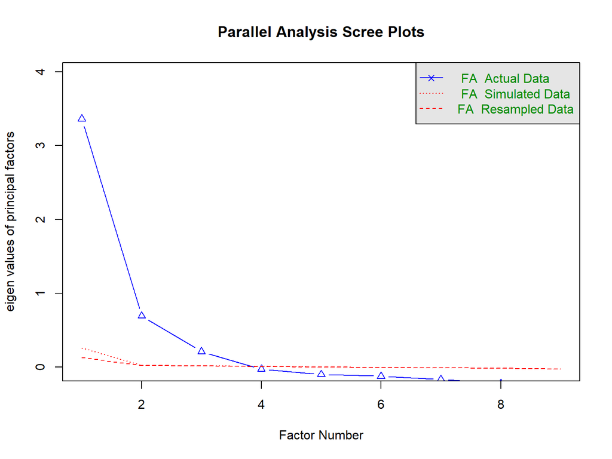

```
## Parallel analysis suggests that the number of factors =  3  and the number of components =  NA
```

```r
fa.parallel(df_qme, fa="fa")
```

```r
fa.fit <- psych::fa(r = cor(df_qme), nfactors = 3, fm = "ml", rotate = "promax")
fa.fit
```

```
## Factor Analysis using method =  ml
## Call: psych::fa(r = cor(df_qme), nfactors = 3, rotate = "promax", fm = "ml")
## Standardized loadings (pattern matrix) based upon correlation matrix
##          ML1   ML2   ML3   h2   u2 com
## qme201  0.03  0.66 -0.02 0.44 0.56 1.0
## qme202  0.00  0.75 -0.02 0.55 0.45 1.0
## qme203 -0.02  0.65  0.05 0.46 0.54 1.0
## qme204  0.73  0.03 -0.01 0.54 0.46 1.0
## qme205  0.84  0.02 -0.06 0.64 0.36 1.0
## qme206  0.69 -0.05  0.15 0.61 0.39 1.1
## qme207  0.17  0.03  0.54 0.48 0.52 1.2
## qme208  0.04 -0.08  0.78 0.58 0.42 1.0
## qme209 -0.05  0.11  0.63 0.45 0.55 1.1
##
##                        ML1  ML2  ML3
## SS loadings           1.84 1.46 1.44
## Proportion Var        0.20 0.16 0.16
## Cumulative Var        0.20 0.37 0.53
## Proportion Explained  0.39 0.31 0.30
## Cumulative Proportion 0.39 0.70 1.00
##
##  With factor correlations of
##      ML1  ML2  ML3
## ML1 1.00 0.42 0.71
## ML2 0.42 1.00 0.59
## ML3 0.71 0.59 1.00
##
## Mean item complexity =  1.1
## Test of the hypothesis that 3 factors are sufficient.
##
## df null model =  36  with the objective function =  3.04
## df of  the model are 12  and the objective function was  0.01
##
## The root mean square of the residuals (RMSR) is  0.01
## The df corrected root mean square of the residuals is  0.01
##
## Fit based upon off diagonal values = 1
## Measures of factor score adequacy
##                                                    ML1  ML2  ML3
## Correlation of (regression) scores with factors   0.92 0.87 0.89
## Multiple R square of scores with factors          0.84 0.76 0.80
## Minimum correlation of possible factor scores     0.68 0.53 0.60
```

```r
fa.fit <- psych::fa(r = cor(df_qme), nfactors = 2, fm = "ml", rotate = "promax")
fa.fit
```

```
## Factor Analysis using method =  ml
## Call: psych::fa(r = cor(df_qme), nfactors = 2, rotate = "promax", fm = "ml")
## Standardized loadings (pattern matrix) based upon correlation matrix
##          ML1   ML2   h2   u2 com
## qme201 -0.03  0.67 0.43 0.57 1.0
## qme202 -0.06  0.75 0.52 0.48 1.0
## qme203 -0.03  0.70 0.46 0.54 1.0
## qme204  0.76 -0.08 0.51 0.49 1.0
## qme205  0.82 -0.11 0.58 0.42 1.0
## qme206  0.86 -0.12 0.63 0.37 1.0
## qme207  0.55  0.17 0.43 0.57 1.2
## qme208  0.55  0.15 0.42 0.58 1.1
## qme209  0.37  0.30 0.35 0.65 1.9
##
##                        ML1  ML2
## SS loadings           2.69 1.64
## Proportion Var        0.30 0.18
## Cumulative Var        0.30 0.48
## Proportion Explained  0.62 0.38
## Cumulative Proportion 0.62 1.00
##
##  With factor correlations of
##      ML1  ML2
## ML1 1.00 0.58
## ML2 0.58 1.00
##
## Mean item complexity =  1.2
## Test of the hypothesis that 2 factors are sufficient.
##
## df null model =  36  with the objective function =  3.04
## df of  the model are 19  and the objective function was  0.13
##
## The root mean square of the residuals (RMSR) is  0.04
## The df corrected root mean square of the residuals is  0.05
##
## Fit based upon off diagonal values = 0.99
## Measures of factor score adequacy
##                                                    ML1  ML2
## Correlation of (regression) scores with factors   0.93 0.88
## Multiple R square of scores with factors          0.86 0.78
## Minimum correlation of possible factor scores     0.72 0.56
```

```r
qme_items_20 <- paste0(qme_items, "_20")
df5$fermotiv1 <- rowMeans(df5[,qme_items_20[1:3]])
df5$fermotiv2 <- rowMeans(df5[,qme_items_20[4:6]])
df5$fermotiv3 <- rowMeans(df5[,qme_items_20[7:9]])
nrow(df5)
```

```
## [1] 9955
```

```r
my.lme3 <- lmer(env_expavg2 ~ scale(qka202,scale=F) + scale(age, scale=F) + scale(qme202_20, scale=F) + scale(finc_corrected, scale=F) +scale(fexp_corrected,scale=F)+scale(fermotiv1,scale=F)+scale(fermotiv2,scale=F)+scale(fermotiv3,scale=F) +(1|provcd18.x) ,data=df5,REML=F)
my.lme3 <- lmer(env_expavg2 ~ qka202+age+finc_corrected+fexp_corrected+fermotiv1+fermotiv2+fermotiv3 +(1|provcd18.x) ,data=df5,REML=F)
summary(my.lme3)
```

```
## Linear mixed model fit by maximum likelihood . t-tests use Satterthwaite's
##   method [lmerModLmerTest]
## Formula: env_expavg2 ~ qka202 + age + finc_corrected + fexp_corrected +
##     fermotiv1 + fermotiv2 + fermotiv3 + (1 | provcd18.x)
##    Data: df5
##
##      AIC      BIC   logLik deviance df.resid
## 105930.3 106001.5 -52955.1 105910.3     9138
##
## Scaled residuals:
##     Min      1Q  Median      3Q     Max
## -2.1248 -0.5029 -0.2289  0.1937 30.3805
##
## Random effects:
##  Groups     Name        Variance Std.Dev.
##  provcd18.x (Intercept)  189.1   13.75
##  Residual               6199.3   78.74
## Number of obs: 9148, groups:  provcd18.x, 208
##
## Fixed effects:
##                  Estimate Std. Error         df t value Pr(>|t|)
## (Intercept)     9.152e+01  8.673e+00  5.099e+03  10.552  < 2e-16 ***
## qka202         -4.083e+00  1.187e+00  9.072e+03  -3.440 0.000584 ***
## age             3.243e-01  6.502e-02  9.021e+03   4.987 6.23e-07 ***
## finc_corrected  8.682e-05  1.312e-05  9.135e+03   6.615 3.91e-11 ***
## fexp_corrected  3.802e-05  1.521e-05  9.133e+03   2.500 0.012445 *
## fermotiv1      -6.484e+00  2.042e+00  9.148e+03  -3.175 0.001502 **
## fermotiv2      -5.342e+00  2.914e+00  9.136e+03  -1.833 0.066804 .
## fermotiv3       2.014e+00  2.992e+00  9.126e+03   0.673 0.500971
## ---
## Signif. codes:  0 '***' 0.001 '**' 0.01 '*' 0.05 '.' 0.1 ' ' 1
##
## Correlation of Fixed Effects:
##             (Intr) qka202 age    fnc_cr fxp_cr frmtv1 frmtv2
## qka202      -0.130
## age         -0.128 -0.264
## finc_crrctd -0.121  0.031  0.058
## fexp_crrctd -0.068  0.000  0.024 -0.523
## fermotiv1   -0.144 -0.080 -0.231  0.084  0.053
## fermotiv2   -0.434 -0.009  0.079 -0.029 -0.010 -0.107
## fermotiv3   -0.255  0.000 -0.056  0.009  0.005 -0.314 -0.542
## fit warnings:
## Some predictor variables are on very different scales: consider rescaling
```

```r
my.lme3 <- lmer(env_expavg2 ~ qka202+age+finc_corrected+fexp_corrected+fermotiv1+fermotiv2+fermotiv3+qka202:fermotiv1+qka202:fermotiv2+qka202:fermotiv3 +(1|provcd18.x) ,data=df5,REML=F)
summary(my.lme3)
```

```
## Linear mixed model fit by maximum likelihood . t-tests use Satterthwaite's
##   method [lmerModLmerTest]
## Formula: env_expavg2 ~ qka202 + age + finc_corrected + fexp_corrected +
##     fermotiv1 + fermotiv2 + fermotiv3 + qka202:fermotiv1 + qka202:fermotiv2 +
##     qka202:fermotiv3 + (1 | provcd18.x)
##    Data: df5
##
##      AIC      BIC   logLik deviance df.resid
## 105931.7 106024.3 -52952.9 105905.7     9135
##
## Scaled residuals:
##     Min      1Q  Median      3Q     Max
## -2.1399 -0.5012 -0.2306  0.1961 30.3840
##
## Random effects:
##  Groups     Name        Variance Std.Dev.
##  provcd18.x (Intercept)  188.9   13.74
##  Residual               6196.2   78.72
## Number of obs: 9148, groups:  provcd18.x, 208
##
## Fixed effects:
##                    Estimate Std. Error         df t value Pr(>|t|)
## (Intercept)       1.029e+02  1.954e+01  8.989e+03   5.267 1.42e-07 ***
## qka202           -9.554e+00  8.892e+00  9.129e+03  -1.074   0.2827
## age               3.254e-01  6.509e-02  9.025e+03   5.000 5.85e-07 ***
## finc_corrected    8.727e-05  1.312e-05  9.135e+03   6.649 3.11e-11 ***
## fexp_corrected    3.804e-05  1.521e-05  9.133e+03   2.501   0.0124 *
## fermotiv1         1.516e-01  5.154e+00  9.133e+03   0.029   0.9765
## fermotiv2        -9.187e-01  7.851e+00  9.125e+03  -0.117   0.9068
## fermotiv3        -1.254e+01  7.973e+00  9.123e+03  -1.573   0.1158
## qka202:fermotiv1 -3.465e+00  2.531e+00  9.129e+03  -1.369   0.1710
## qka202:fermotiv2 -2.289e+00  3.769e+00  9.126e+03  -0.607   0.5436
## qka202:fermotiv3  7.423e+00  3.788e+00  9.125e+03   1.960   0.0500 .
## ---
## Signif. codes:  0 '***' 0.001 '**' 0.01 '*' 0.05 '.' 0.1 ' ' 1
##
## Correlation of Fixed Effects:
##             (Intr) qka202 age    fnc_cr fxp_cr frmtv1 frmtv2 frmtv3 q202:1
## qka202      -0.896
## age         -0.061 -0.029
## finc_crrctd -0.051  0.001  0.057
## fexp_crrctd -0.031  0.002  0.025 -0.523
## fermotiv1   -0.151  0.155 -0.055  0.036  0.029
## fermotiv2   -0.440  0.400  0.001  0.002 -0.010 -0.120
## fermotiv3   -0.231  0.203 -0.011 -0.014  0.005 -0.364 -0.586
## qk202:frmt1  0.140 -0.177 -0.040 -0.003 -0.008 -0.918  0.129  0.327
## qk202:frmt2  0.382 -0.413  0.031 -0.015  0.008  0.125 -0.928  0.554 -0.154
## qk202:frmt3  0.195 -0.210 -0.011  0.019 -0.004  0.337  0.560 -0.927 -0.347
##             q202:2
## qka202
## age
## finc_crrctd
## fexp_crrctd
## fermotiv1
## fermotiv2
## fermotiv3
## qk202:frmt1
## qk202:frmt2
## qk202:frmt3 -0.607
## fit warnings:
## Some predictor variables are on very different scales: consider rescaling
```

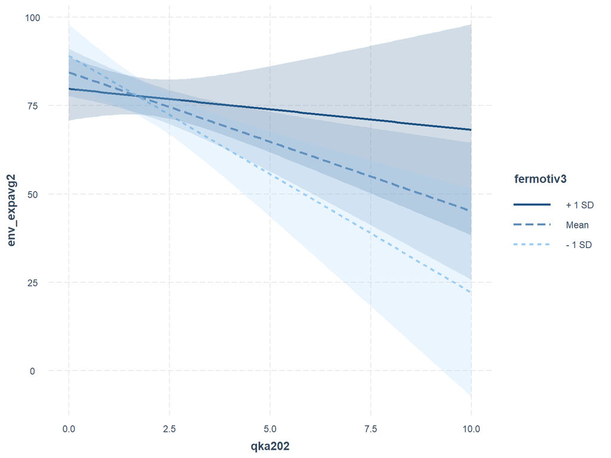

```r
interact_plot(my.lme3, pred = qka202, modx = fermotiv3, interval = TRUE)
```

```r
#my.lme3 <- lmer(qme202_20 ~ scale(qka202,scale=F) + scale(age, scale=F) + scale(qme202_20, scale=F) + scale(finc_corrected, scale=F) +scale(fexp_corrected,scale=F)+scale(fermotiv1,scale=F)+(1|provcd18.x) ,data=df5,REML=F)
```

# 城乡

```r
attr(df1_person18$urban18, "label")
```

```
## [1] "基于国家统计局资料的城乡分类"
```

```r
attr(df1_person18$urban18, "labels")
```

```
## 无法判断     缺失   不适用 拒绝回答   不知道     乡村     城镇
##      -10       -9       -8       -2       -1        0        1
```

```r
my.lme2 <- lmer(env_expavg2 ~ qka202 +age +finc_corrected+fexp_corrected+urban18.y +qka202:urban18.y +(1|provcd18.x) ,data=df6,REML=F)
summary(my.lme2)
```

```
## Linear mixed model fit by maximum likelihood . t-tests use Satterthwaite's
##   method [lmerModLmerTest]
## Formula: env_expavg2 ~ qka202 + age + finc_corrected + fexp_corrected +
##     urban18.y + qka202:urban18.y + (1 | provcd18.x)
##    Data: df6
##
##      AIC      BIC   logLik deviance df.resid
## 109298.8 109363.3 -54640.4 109280.8     9554
##
## Scaled residuals:
##     Min      1Q  Median      3Q     Max
## -1.9651 -0.5295 -0.2374  0.2065 12.4198
##
## Random effects:
##  Groups     Name        Variance Std.Dev.
##  provcd18.x (Intercept)  154     12.41
##  Residual               5338     73.06
## Number of obs: 9563, groups:  provcd18.x, 207
##
## Fixed effects:
##                    Estimate Std. Error         df t value Pr(>|t|)
## (Intercept)       6.198e+01  4.218e+00  1.100e+03  14.693  < 2e-16 ***
## qka202           -6.443e+00  1.386e+00  9.559e+03  -4.650 3.36e-06 ***
## age               2.932e-01  5.646e-02  9.433e+03   5.193 2.12e-07 ***
## finc_corrected    7.375e-05  1.231e-05  9.551e+03   5.993 2.14e-09 ***
## fexp_corrected    3.523e-05  1.358e-05  9.548e+03   2.595 0.009477 **
## urban18.y        -9.361e-01  4.418e+00  9.557e+03  -0.212 0.832205
## qka202:urban18.y  6.978e+00  2.026e+00  9.558e+03   3.445 0.000575 ***
## ---
## Signif. codes:  0 '***' 0.001 '**' 0.01 '*' 0.05 '.' 0.1 ' ' 1
##
## Correlation of Fixed Effects:
##             (Intr) qka202 age    fnc_cr fxp_cr urb18.
## qka202      -0.572
## age         -0.455 -0.228
## finc_crrctd -0.153  0.015  0.085
## fexp_crrctd -0.070  0.001  0.041 -0.519
## urban18.y   -0.500  0.617  0.017 -0.052 -0.011
## qk202:rb18.  0.452 -0.623 -0.016  0.004  0.000 -0.931
## fit warnings:
## Some predictor variables are on very different scales: consider rescaling
```

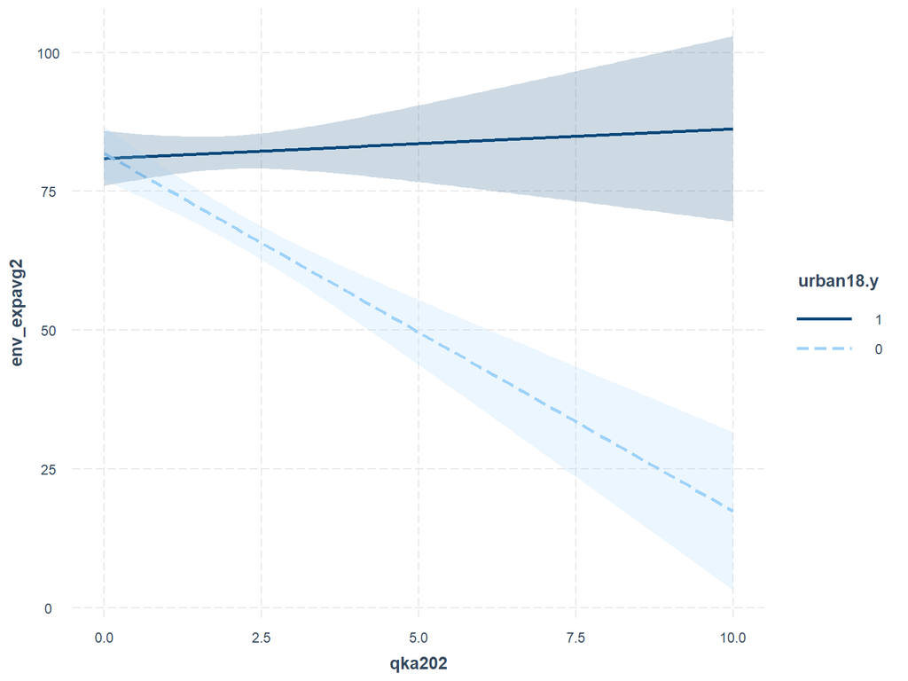

```r
interact_plot(my.lme2, pred = qka202, modx = urban18.y, interval = TRUE,
              int.width = 0.8)
```

```r
print(df6$urban18.y)
```

[output not shown]

[output cut: 544 more lines]

```r
my.lme2 <- lmer(env_expavg2_20 ~ qka202 +age +finc_corrected+fexp_corrected+urban18.y +qka202:urban18.y +(1|provcd18.x) ,data=df6,REML=F)
summary(my.lme2)
```

```
## Linear mixed model fit by maximum likelihood . t-tests use Satterthwaite's
##   method [lmerModLmerTest]
## Formula: env_expavg2_20 ~ qka202 + age + finc_corrected + fexp_corrected +
##     urban18.y + qka202:urban18.y + (1 | provcd18.x)
##    Data: df6
##
##      AIC      BIC   logLik deviance df.resid
## 110438.2 110502.6 -55210.1 110420.2     9453
##
## Scaled residuals:
##     Min      1Q  Median      3Q     Max
## -2.1891 -0.5137 -0.2402  0.1979 18.4716
##
## Random effects:
##  Groups     Name        Variance Std.Dev.
##  provcd18.x (Intercept)  242.3   15.57
##  Residual               6796.3   82.44
## Number of obs: 9462, groups:  provcd18.x, 208
##
## Fixed effects:
##                    Estimate Std. Error         df t value Pr(>|t|)
## (Intercept)       5.759e+01  4.847e+00  1.033e+03  11.881  < 2e-16 ***
## qka202           -4.808e+00  1.571e+00  9.462e+03  -3.060  0.00222 **
## age               3.309e-01  6.403e-02  9.383e+03   5.168 2.41e-07 ***
## finc_corrected    6.774e-05  1.365e-05  9.460e+03   4.964 7.03e-07 ***
## fexp_corrected    2.107e-05  1.567e-05  9.440e+03   1.345  0.17866
## urban18.y         4.729e+00  4.975e+00  9.460e+03   0.951  0.34186
## qka202:urban18.y  6.153e+00  2.277e+00  9.454e+03   2.702  0.00690 **
## ---
## Signif. codes:  0 '***' 0.001 '**' 0.01 '*' 0.05 '.' 0.1 ' ' 1
##
## Correlation of Fixed Effects:
##             (Intr) qka202 age    fnc_cr fxp_cr urb18.
## qka202      -0.566
## age         -0.444 -0.228
## finc_crrctd -0.142  0.019  0.078
## fexp_crrctd -0.062 -0.005  0.042 -0.545
## urban18.y   -0.500  0.621  0.022 -0.037 -0.020
## qk202:rb18.  0.453 -0.628 -0.020 -0.009  0.007 -0.930
## fit warnings:
## Some predictor variables are on very different scales: consider rescaling
```

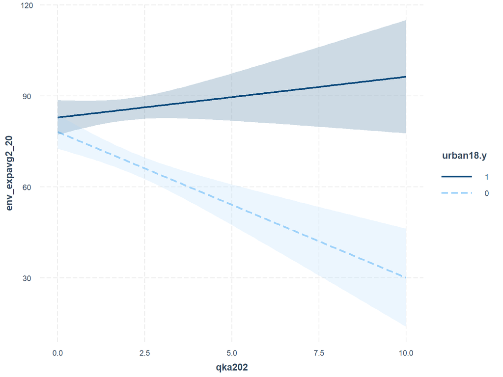

```r
interact_plot(my.lme2, pred = qka202, modx = urban18.y, interval = TRUE,
              int.width = 0.8)
```

```r
df6$urban18.r <- dplyr::recode(df6$urban18.y, `1` = 0, `0` = 1)
my.lme2 <- lmer(env_expavg2_20 ~ qka202 +age +finc_corrected+fexp_corrected+urban18.r +qka202:urban18.r +(1|provcd18.x) ,data=df6,REML=F)
summary(my.lme2)
```

```
## Linear mixed model fit by maximum likelihood . t-tests use Satterthwaite's
##   method [lmerModLmerTest]
## Formula: env_expavg2_20 ~ qka202 + age + finc_corrected + fexp_corrected +
##     urban18.r + qka202:urban18.r + (1 | provcd18.x)
##    Data: df6
##
##      AIC      BIC   logLik deviance df.resid
## 110438.2 110502.6 -55210.1 110420.2     9453
##
## Scaled residuals:
##     Min      1Q  Median      3Q     Max
## -2.1891 -0.5137 -0.2402  0.1979 18.4716
##
## Random effects:
##  Groups     Name        Variance Std.Dev.
##  provcd18.x (Intercept)  242.3   15.57
##  Residual               6796.3   82.44
## Number of obs: 9462, groups:  provcd18.x, 208
##
## Fixed effects:
##                    Estimate Std. Error         df t value Pr(>|t|)
## (Intercept)       6.231e+01  4.910e+00  9.204e+02  12.691  < 2e-16 ***
## qka202            1.345e+00  1.777e+00  9.440e+03   0.757   0.4491
## age               3.309e-01  6.403e-02  9.383e+03   5.168 2.41e-07 ***
## finc_corrected    6.774e-05  1.365e-05  9.460e+03   4.964 7.03e-07 ***
## fexp_corrected    2.107e-05  1.567e-05  9.440e+03   1.345   0.1787
## urban18.r        -4.729e+00  4.975e+00  9.460e+03  -0.951   0.3419
## qka202:urban18.r -6.153e+00  2.277e+00  9.454e+03  -2.702   0.0069 **
## ---
## Signif. codes:  0 '***' 0.001 '**' 0.01 '*' 0.05 '.' 0.1 ' ' 1
##
## Correlation of Fixed Effects:
##             (Intr) qka202 age    fnc_cr fxp_cr urb18.
## qka202      -0.573
## age         -0.416 -0.227
## finc_crrctd -0.178  0.005  0.078
## fexp_crrctd -0.081  0.004  0.042 -0.545
## urban18.r   -0.519  0.643 -0.022  0.037  0.020
## qk202:rb18.  0.495 -0.726  0.020  0.009 -0.007 -0.930
## fit warnings:
## Some predictor variables are on very different scales: consider rescaling
```

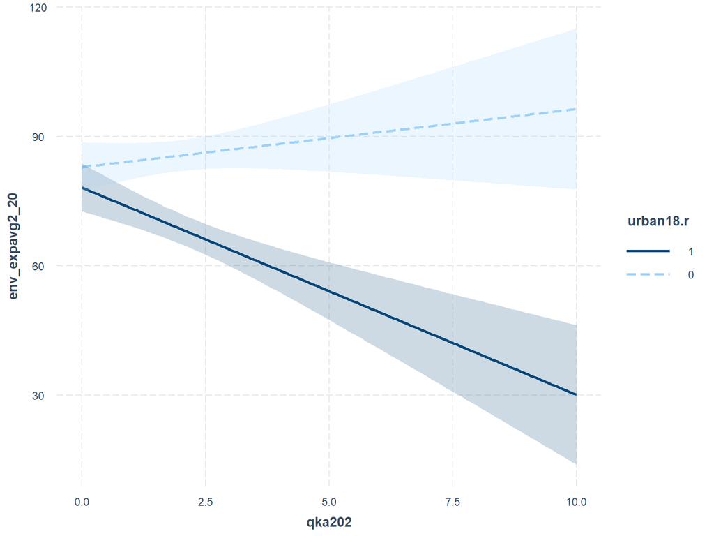

```r
interact_plot(my.lme2, pred = qka202, modx = urban18.r, interval = TRUE,
              int.width = 0.8)
```

```r
attr(df_qme$qme202, "label")
```

```
## [1] "为了延续家族香火"
```

```r
my.lme3 <- lmer(env_expavg2_20 ~ qka202 +age +finc_corrected+fexp_corrected+qme202_20  +(1|provcd18.x) ,data=df6,REML=F)
summary(my.lme3)
```

```
## Linear mixed model fit by maximum likelihood . t-tests use Satterthwaite's
##   method [lmerModLmerTest]
## Formula: env_expavg2_20 ~ qka202 + age + finc_corrected + fexp_corrected +
##     qme202_20 + (1 | provcd18.x)
##    Data: df6
##
##      AIC      BIC   logLik deviance df.resid
## 108263.8 108320.9 -54123.9 108247.8     9265
##
## Scaled residuals:
##     Min      1Q  Median      3Q     Max
## -2.2876 -0.5174 -0.2463  0.2001 18.5451
##
## Random effects:
##  Groups     Name        Variance Std.Dev.
##  provcd18.x (Intercept)  283.8   16.85
##  Residual               6815.8   82.56
## Number of obs: 9273, groups:  provcd18.x, 207
##
## Fixed effects:
##                  Estimate Std. Error         df t value Pr(>|t|)
## (Intercept)     7.693e+01  5.808e+00  1.450e+03  13.244  < 2e-16 ***
## qka202         -3.110e+00  1.268e+00  9.232e+03  -2.453   0.0142 *
## age             4.121e-01  6.729e-02  9.211e+03   6.124 9.50e-10 ***
## finc_corrected  7.585e-05  1.373e-05  9.270e+03   5.524 3.41e-08 ***
## fexp_corrected  2.638e-05  1.579e-05  9.249e+03   1.671   0.0947 .
## qme202_20      -6.910e+00  1.538e+00  9.268e+03  -4.493 7.11e-06 ***
## ---
## Signif. codes:  0 '***' 0.001 '**' 0.01 '*' 0.05 '.' 0.1 ' ' 1
##
## Correlation of Fixed Effects:
##             (Intr) qka202 age    fnc_cr fxp_cr
## qka202      -0.244
## age         -0.253 -0.284
## finc_crrctd -0.187  0.035  0.067
## fexp_crrctd -0.085 -0.002  0.034 -0.550
## qme202_20   -0.658 -0.082 -0.174  0.064  0.038
## fit warnings:
## Some predictor variables are on very different scales: consider rescaling
```

```r
my.lme4 <- lmer(env_expavg2_20 ~ qka202 +age +finc_corrected+fexp_corrected+qme202_20 + qme202_20:qka202 +(1|provcd18.x) ,data=df6,REML=F)
summary(my.lme4)
```

```
## Linear mixed model fit by maximum likelihood . t-tests use Satterthwaite's
##   method [lmerModLmerTest]
## Formula: env_expavg2_20 ~ qka202 + age + finc_corrected + fexp_corrected +
##     qme202_20 + qme202_20:qka202 + (1 | provcd18.x)
##    Data: df6
##
##      AIC      BIC   logLik deviance df.resid
## 108261.7 108325.9 -54121.8 108243.7     9264
##
## Scaled residuals:
##     Min      1Q  Median      3Q     Max
## -2.2867 -0.5167 -0.2436  0.2036 18.5637
##
## Random effects:
##  Groups     Name        Variance Std.Dev.
##  provcd18.x (Intercept)  281.2   16.77
##  Residual               6813.0   82.54
## Number of obs: 9273, groups:  provcd18.x, 207
##
## Fixed effects:
##                    Estimate Std. Error         df t value Pr(>|t|)
## (Intercept)       9.838e+01  1.203e+01  7.295e+03   8.175 3.46e-16 ***
## qka202           -1.466e+01  5.827e+00  9.256e+03  -2.516 0.011881 *
## age               4.092e-01  6.729e-02  9.210e+03   6.082 1.24e-09 ***
## finc_corrected    7.601e-05  1.373e-05  9.269e+03   5.536 3.18e-08 ***
## fexp_corrected    2.658e-05  1.578e-05  9.249e+03   1.684 0.092248 .
## qme202_20        -1.414e+01  3.877e+00  9.252e+03  -3.647 0.000267 ***
## qka202:qme202_20  3.886e+00  1.914e+00  9.250e+03   2.031 0.042301 *
## ---
## Signif. codes:  0 '***' 0.001 '**' 0.01 '*' 0.05 '.' 0.1 ' ' 1
##
## Correlation of Fixed Effects:
##             (Intr) qka202 age    fnc_cr fxp_cr q202_2
## qka202      -0.881
## age         -0.141 -0.041
## finc_crrctd -0.086  0.003  0.067
## fexp_crrctd -0.036 -0.006  0.034 -0.550
## qme202_20   -0.930  0.889 -0.049  0.021  0.010
## q202:202_20  0.876 -0.976 -0.022  0.005  0.006 -0.918
## fit warnings:
## Some predictor variables are on very different scales: consider rescaling
```

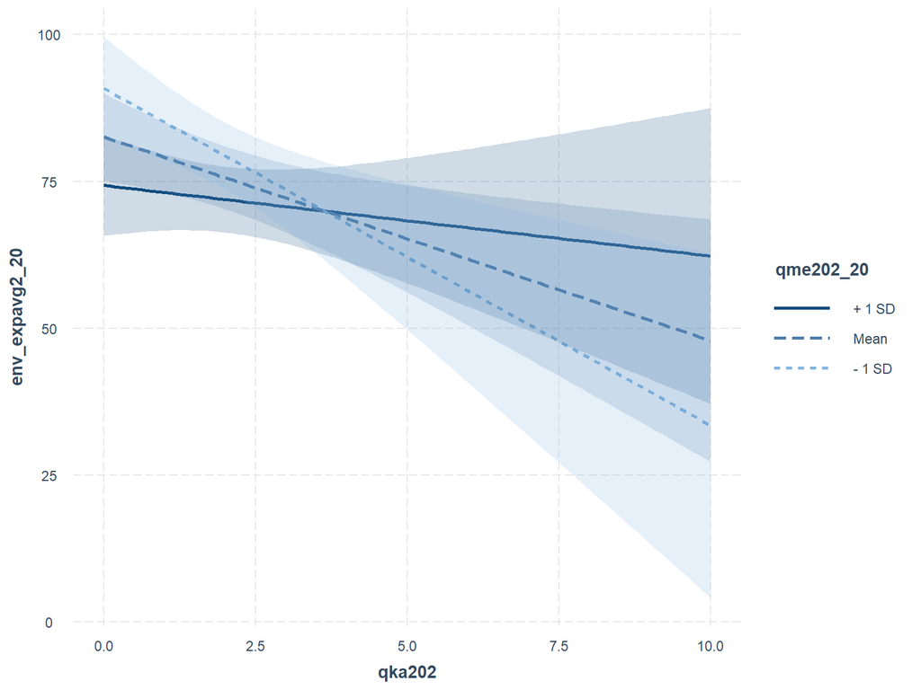

```r
interact_plot(my.lme4, pred = qka202, modx = qme202_20, interval = TRUE)
```

```r
my.lme5 <- lmer(env_expavg2_20 ~ qka202 +age +finc_corrected+fexp_corrected+qme202_20 + urban18.y + qme202_20:qka202 +qka202:urban18.y+qme202_20:urban18.y +(1|provcd18.x) ,data=df6,REML=F)
summary(my.lme5)
```

```
## Linear mixed model fit by maximum likelihood . t-tests use Satterthwaite's
##   method [lmerModLmerTest]
## Formula: env_expavg2_20 ~ qka202 + age + finc_corrected + fexp_corrected +
##     qme202_20 + urban18.y + qme202_20:qka202 + qka202:urban18.y +
##     qme202_20:urban18.y + (1 | provcd18.x)
##    Data: df6
##
##      AIC      BIC   logLik deviance df.resid
## 107068.4 107153.9 -53522.2 107044.4     9171
##
## Scaled residuals:
##     Min      1Q  Median      3Q     Max
## -2.1362 -0.5125 -0.2381  0.1964 18.6109
##
## Random effects:
##  Groups     Name        Variance Std.Dev.
##  provcd18.x (Intercept)  235.9   15.36
##  Residual               6707.6   81.90
## Number of obs: 9183, groups:  provcd18.x, 207
##
## Fixed effects:
##                       Estimate Std. Error         df t value Pr(>|t|)
## (Intercept)          1.104e+02  1.498e+01  8.617e+03   7.369 1.87e-13 ***
## qka202              -2.107e+01  6.362e+00  9.160e+03  -3.311 0.000932 ***
## age                  4.238e-01  6.718e-02  9.093e+03   6.309 2.94e-10 ***
## finc_corrected       6.437e-05  1.375e-05  9.180e+03   4.681 2.89e-06 ***
## fexp_corrected       2.181e-05  1.569e-05  9.161e+03   1.390 0.164650
## qme202_20           -1.909e+01  4.715e+00  9.157e+03  -4.048 5.21e-05 ***
## urban18.y           -1.729e+01  1.014e+01  9.176e+03  -1.705 0.088215 .
## qka202:qme202_20     5.456e+00  1.997e+00  9.159e+03   2.732 0.006309 **
## qka202:urban18.y     6.970e+00  2.446e+00  9.175e+03   2.850 0.004387 **
## qme202_20:urban18.y  6.599e+00  3.128e+00  9.166e+03   2.109 0.034942 *
## ---
## Signif. codes:  0 '***' 0.001 '**' 0.01 '*' 0.05 '.' 0.1 ' ' 1
##
## Correlation of Fixed Effects:
##             (Intr) qka202 age    fnc_cr fxp_cr qm202_20 urb18. q202:2 q202:1
## qka202      -0.852
## age         -0.119 -0.031
## finc_crrctd -0.046 -0.003  0.070
## fexp_crrctd -0.022 -0.009  0.035 -0.541
## qme202_20   -0.942  0.829 -0.038  0.000  0.002
## urban18.y   -0.595  0.326  0.003 -0.041 -0.012  0.557
## q202:202_20  0.840 -0.967 -0.024  0.008  0.008 -0.867   -0.272
## qk202:rb18.  0.279 -0.347 -0.017 -0.003  0.001 -0.137   -0.409  0.197
## q202_20:18.  0.487 -0.167  0.002  0.023  0.006 -0.535   -0.854  0.192 -0.089
## fit warnings:
## Some predictor variables are on very different scales: consider rescaling
```

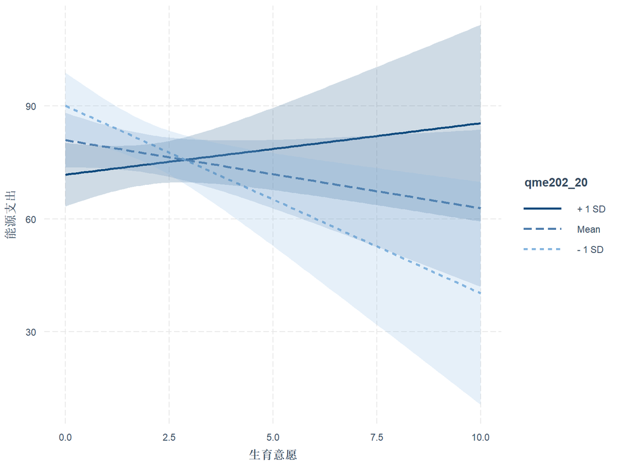

```r
interact_plot(my.lme5, pred = qka202, modx = qme202_20, interval = TRUE, x.label="生育意愿",y.label="能源支出",modx.labels = "传统观念")
```

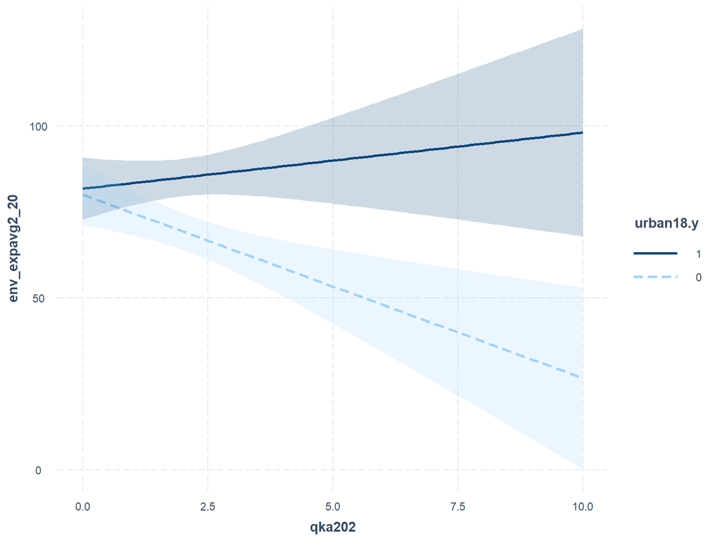

```r
interact_plot(my.lme5, pred = qka202, modx = urban18.y, interval = TRUE)
```

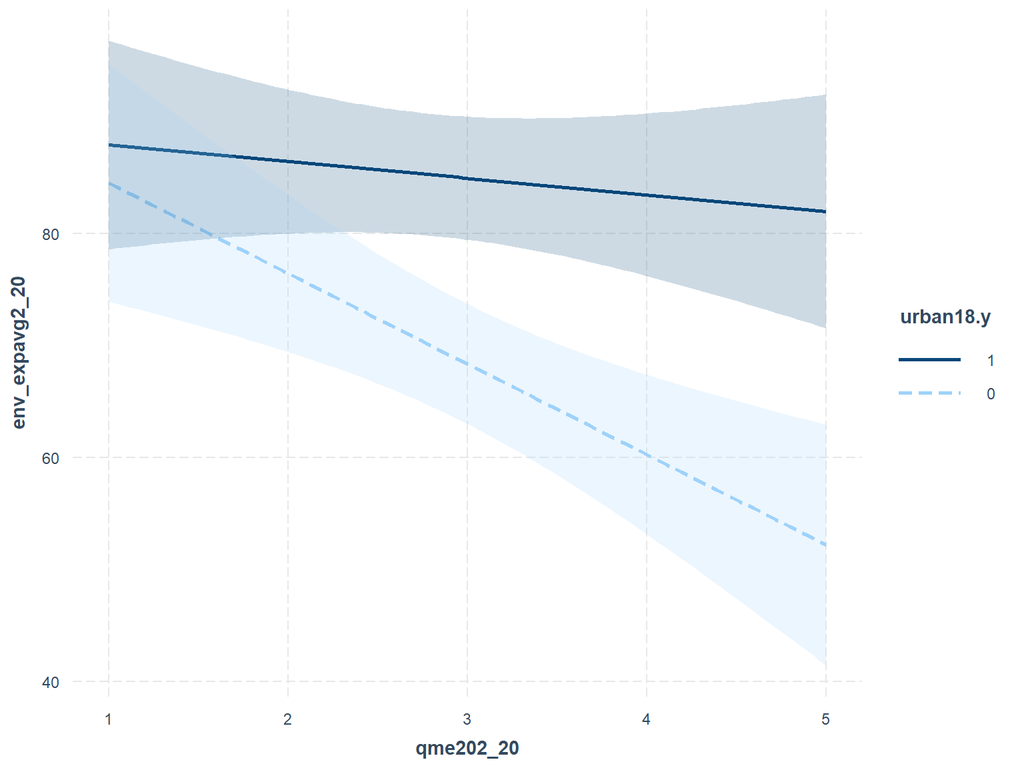

```r
interact_plot(my.lme5, pred = qme202_20, modx = urban18.y, interval = TRUE)
```